# An Introduction to Python

### Jimmy Azar

Python is a general-purpose programming language. It is widely used in data science, statistics, image analysis, web development, and other fields. Important libraries include pandas, numpy, scipy, scikit-learn, scikit-image, etc. The primary purpose of this lab is to introduce Python.

## Getting started with Python

Python is preinstalled on most Linux distibutions. It is also available for download from:

https://www.python.org/

Start Python through your favorite IDE (PyCharm, Spyder, PyDev/Eclipse, Jupyter, Vim, Geany, etc.).

### Simple calculations, vectors and graphics

To begin with, we’ll use Python as a calculator. Try the following commands:

```python
import numpy as np

2+7

2/(3+5)

np.sqrt(9) + 5**2

np.sin(np.pi/2) - np.log(np.exp(1));
```

Help about a specific command can be found by using the help() function, for instance:

help(np.log) #press q to quit in console

np.info(np.log) #try this also

help(np.log) #press q to quit in console

np.info(np.log) #try this also

Comments can be written using the # symbol as follows:

```python
2+3 #this is a comment
```

```
5
```

### Vectors and matrices

Vectors and matrices are of great importance in many numerical problems. To create a vector named "vec" and assign the values 7, −2, 5, 8 to it, we write as follows:

```python
vec = np.array([7,-2,5,8])
```

You can now look at the vector "vec" by typing:

```python
vec
```

```
array([ 7, -2,  5,  8])
```

Array indices start at 0, so the second element of the vector can be referred to by the command:

```python
vec[1]
```

```
-2
```

and the 2nd to 4th elements by:

```python
vec[1:4]    #last index (4) is never included
```

```
array([-2,  5,  8])
```

Vectors can be manipulated, for instance by adding a constant to all elements, as follows:

```python
cst = 100; vec + cst   #semicolon allows multiple commands on a single line
```

```
array([107,  98, 105, 108])
```

A vector $x$ consisting of the integers between 1 and 10 (i.e. 1, 2, ..., 10) can be created by writing:

```python
x = np.arange(1,11)
x
```

```
array([ 1,  2,  3,  4,  5,  6,  7,  8,  9, 10])
```

Vectors with sequences of numbers with particular increments can be created with **np.arange()**:

```python
h = np.arange(0,11,2)  #by increments of 2
h
```

```
array([ 0,  2,  4,  6,  8, 10])
```

The function **np.stack()** can be used to merge row or column vectors to matrices. Try the following:

```python
x = np.array([1,2,3]); y=np.array([4,5,6])
A = np.stack([x,y],axis=1) #or: A = np.c_[x,y]
B = np.stack([x,y])
C = B.T
```

The last command above gives the matrix transpose of B. Now type A, B and C to see what the different matrices look like.

Matrix multiplication is performed using **dot()** (e.g. B.dot(x)) or **np.matmul()**, and matrices can be inverted using **np.linalg.inv()**

```python
B.dot(x)
np.matmul(B,x)
```

```
array([14, 32])
```

```python
D = np.array([[1,4,5],[1,9,6],[8,5,0]])
np.linalg.inv(D)
```

```
array([[ 0.1734104 , -0.14450867,  0.12138728],
       [-0.27745665,  0.23121387,  0.00578035],
       [ 0.38728324, -0.15606936, -0.02890173]])
```

### Simple graphics

Graphs of functions can be drawn by constructing suitable vectors and using matplotlib.

```python
x = np.linspace(0,10,50)
y = np.sqrt(x)

import matplotlib.pyplot as plt
plt.scatter(x,y)
plt.xlabel('x')
plt.ylabel('y')
plt.grid()  #adds a grid to the plot
plt.show()
```

[output not shown]

Make a line plot of the function $y=x^2$ in the interval $-2 \leq x \leq 2$.

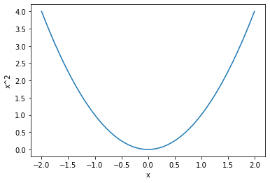

```python
x = np.linspace(-2,2,50)
y = x**2

plt.plot(x,y)
plt.xlabel('x')
plt.ylabel('x^2')
plt.show()
```

## Handling data

### Creating data frames

A data frame using Pandas can be used to organize data of different types and to extract subsets of the data. Assume that we have data about three persons and that we store it as follows:

```python
import pandas as pd

height = [180,175,190]; weight = [75,82,88]; name = ['Adam','Bob','Carl']
friends = pd.DataFrame([name,height,weight],columns=['name','height','weight'])

#alternatively:
data = {'name':['Adam','Bob','Carl'],'height':[180,175,190],'weight':[75,82,88]}  #dictionary approach
friends = pd.DataFrame(data)
friends
```

|  | name | height | weight |
| --- | --- | --- | --- |
| 0 | Adam | 180 | 75 |
| 1 | Bob | 175 | 82 |
| 2 | Carl | 190 | 88 |

"friends" is now a data frame containing the data for the three persons. Data can easily be extracted:

```python
friends['name'].values
```

```
array(['Adam', 'Bob', 'Carl'], dtype=object)
```

```python
height0 = friends['height'][0]
height0
```

```
180
```

## Reading data from files

It is common that data is stored in a text file and that we wish to import the data. We will study two cases; one with purely numerical data and one with numerical data with headers. In the file *coins.dat* data about the amount of silver in 27 silver coins from different epochs is stored. Use **pd.read_fwf()** to create a structure with two columns with headers V1 (amount of silver) and V2 (epoch).

```python
import os
os.getcwd() #get current working directory

path_to_file = './data/coins.dat' #specify path

mynt1 = pd.read_fwf(path_to_file, header=None, names=['V1','V2'])
mynt1.head()
```

|  | V1 | V2 |
| --- | --- | --- |
| 0 | 5.9 | 1 |
| 1 | 6.8 | 1 |
| 2 | 6.4 | 1 |
| 3 | 7.0 | 1 |
| 4 | 6.6 | 1 |

To see the properties of the tenth observation we write:

```python
mynt1.iloc[9].values   #10th row
```

```
array([6.9, 2. ])
```

If we only want to see the amount of silver in the tenth coin we write:

```python
mynt1['V1'][9]
mynt1.iloc[9,0] #alternatively
```

```
6.9
```

Clearly, it’s important to know which data is stored in which column. To make this clear one can give the columns headers when importing the data so that the strings Silver and Epoch will be used instead of V1 and V2:

```python
mynt2 = pd.read_fwf(path_to_file, header=None, names=['Silver','Epoch'])
mynt2.head()
```

|  | Silver | Epoch |
| --- | --- | --- |
| 0 | 5.9 | 1 |
| 1 | 6.8 | 1 |
| 2 | 6.4 | 1 |
| 3 | 7.0 | 1 |
| 4 | 6.6 | 1 |

Let us now study the same dataset, but with the data stored in a slightly different way. The file *coins.txt* has the same data stored, but with headers stored on the first row of the file. To import the data with headers we write:

```python
path_to_file = './data/coins.txt'
mynt2 = pd.read_csv(path_to_file, delim_whitespace=True)    #pd.read_excel() for excel files
mynt2.head()
```

|  | Ag | Epoch |
| --- | --- | --- |
| 0 | 5.9 | 1 |
| 1 | 6.8 | 1 |
| 2 | 6.4 | 1 |
| 3 | 7.0 | 1 |
| 4 | 6.6 | 1 |

## Analysis of a dataset: Cars

We will study a dataset from the early 70's with data about different cars.

Load the dataset by writing:

```python
path_to_file = './data/mtcars.csv'
mtcars = pd.read_csv(path_to_file)
mtcars
```

|  | model | mpg | cyl | disp | hp | drat | wt | qsec | vs | am | gear | carb |
| --- | --- | --- | --- | --- | --- | --- | --- | --- | --- | --- | --- | --- |
| 0 | Mazda RX4 | 21.0 | 6 | 160.0 | 110 | 3.90 | 2.620 | 16.46 | 0 | 1 | 4 | 4 |
| 1 | Mazda RX4 Wag | 21.0 | 6 | 160.0 | 110 | 3.90 | 2.875 | 17.02 | 0 | 1 | 4 | 4 |
| 2 | Datsun 710 | 22.8 | 4 | 108.0 | 93 | 3.85 | 2.320 | 18.61 | 1 | 1 | 4 | 1 |
| 3 | Hornet 4 Drive | 21.4 | 6 | 258.0 | 110 | 3.08 | 3.215 | 19.44 | 1 | 0 | 3 | 1 |
| 4 | Hornet Sportabout | 18.7 | 8 | 360.0 | 175 | 3.15 | 3.440 | 17.02 | 0 | 0 | 3 | 2 |
| 5 | Valiant | 18.1 | 6 | 225.0 | 105 | 2.76 | 3.460 | 20.22 | 1 | 0 | 3 | 1 |
| 6 | Duster 360 | 14.3 | 8 | 360.0 | 245 | 3.21 | 3.570 | 15.84 | 0 | 0 | 3 | 4 |
| 7 | Merc 240D | 24.4 | 4 | 146.7 | 62 | 3.69 | 3.190 | 20.00 | 1 | 0 | 4 | 2 |
| 8 | Merc 230 | 22.8 | 4 | 140.8 | 95 | 3.92 | 3.150 | 22.90 | 1 | 0 | 4 | 2 |
| 9 | Merc 280 | 19.2 | 6 | 167.6 | 123 | 3.92 | 3.440 | 18.30 | 1 | 0 | 4 | 4 |
| 10 | Merc 280C | 17.8 | 6 | 167.6 | 123 | 3.92 | 3.440 | 18.90 | 1 | 0 | 4 | 4 |
| 11 | Merc 450SE | 16.4 | 8 | 275.8 | 180 | 3.07 | 4.070 | 17.40 | 0 | 0 | 3 | 3 |
| 12 | Merc 450SL | 17.3 | 8 | 275.8 | 180 | 3.07 | 3.730 | 17.60 | 0 | 0 | 3 | 3 |
| 13 | Merc 450SLC | 15.2 | 8 | 275.8 | 180 | 3.07 | 3.780 | 18.00 | 0 | 0 | 3 | 3 |
| 14 | Cadillac Fleetwood | 10.4 | 8 | 472.0 | 205 | 2.93 | 5.250 | 17.98 | 0 | 0 | 3 | 4 |
| 15 | Lincoln Continental | 10.4 | 8 | 460.0 | 215 | 3.00 | 5.424 | 17.82 | 0 | 0 | 3 | 4 |
| 16 | Chrysler Imperial | 14.7 | 8 | 440.0 | 230 | 3.23 | 5.345 | 17.42 | 0 | 0 | 3 | 4 |
| 17 | Fiat 128 | 32.4 | 4 | 78.7 | 66 | 4.08 | 2.200 | 19.47 | 1 | 1 | 4 | 1 |
| 18 | Honda Civic | 30.4 | 4 | 75.7 | 52 | 4.93 | 1.615 | 18.52 | 1 | 1 | 4 | 2 |
| 19 | Toyota Corolla | 33.9 | 4 | 71.1 | 65 | 4.22 | 1.835 | 19.90 | 1 | 1 | 4 | 1 |
| 20 | Toyota Corona | 21.5 | 4 | 120.1 | 97 | 3.70 | 2.465 | 20.01 | 1 | 0 | 3 | 1 |
| 21 | Dodge Challenger | 15.5 | 8 | 318.0 | 150 | 2.76 | 3.520 | 16.87 | 0 | 0 | 3 | 2 |
| 22 | AMC Javelin | 15.2 | 8 | 304.0 | 150 | 3.15 | 3.435 | 17.30 | 0 | 0 | 3 | 2 |
| 23 | Camaro Z28 | 13.3 | 8 | 350.0 | 245 | 3.73 | 3.840 | 15.41 | 0 | 0 | 3 | 4 |
| 24 | Pontiac Firebird | 19.2 | 8 | 400.0 | 175 | 3.08 | 3.845 | 17.05 | 0 | 0 | 3 | 2 |
| 25 | Fiat X1-9 | 27.3 | 4 | 79.0 | 66 | 4.08 | 1.935 | 18.90 | 1 | 1 | 4 | 1 |
| 26 | Porsche 914-2 | 26.0 | 4 | 120.3 | 91 | 4.43 | 2.140 | 16.70 | 0 | 1 | 5 | 2 |
| 27 | Lotus Europa | 30.4 | 4 | 95.1 | 113 | 3.77 | 1.513 | 16.90 | 1 | 1 | 5 | 2 |
| 28 | Ford Pantera L | 15.8 | 8 | 351.0 | 264 | 4.22 | 3.170 | 14.50 | 0 | 1 | 5 | 4 |
| 29 | Ferrari Dino | 19.7 | 6 | 145.0 | 175 | 3.62 | 2.770 | 15.50 | 0 | 1 | 5 | 6 |
| 30 | Maserati Bora | 15.0 | 8 | 301.0 | 335 | 3.54 | 3.570 | 14.60 | 0 | 1 | 5 | 8 |
| 31 | Volvo 142E | 21.4 | 4 | 121.0 | 109 | 4.11 | 2.780 | 18.60 | 1 | 1 | 4 | 2 |

1. Are there any cars that weigh more than 5000 (lb/1000)?
2. How many cylinders does the motor of the Volvo 142E have?
3. Are there any cars with 5 forward gears? Do they have automatic or manual transmission?
4. Experiment with the below commands: what do the commands do?

```python
mtcars[mtcars['gear']==5]
mtcars[(mtcars['wt']>5) & (mtcars['disp']<470)]
```

|  | model | mpg | cyl | disp | hp | drat | wt | qsec | vs | am | gear | carb |
| --- | --- | --- | --- | --- | --- | --- | --- | --- | --- | --- | --- | --- |
| 15 | Lincoln Continental | 10.4 | 8 | 460.0 | 215 | 3.00 | 5.424 | 17.82 | 0 | 0 | 3 | 4 |
| 16 | Chrysler Imperial | 14.7 | 8 | 440.0 | 230 | 3.23 | 5.345 | 17.42 | 0 | 0 | 3 | 4 |

### Descriptive statistics

Data can be summarized using simple measures such as the mean, median, standard deviation, maximum and minimum and so on. A summary of a few such measures for the *mtcars* dataset is obtained by writing

```python
type(mtcars) #DataFrame
mtcars.describe()
```

|  | mpg | cyl | disp | hp | drat | wt | qsec | vs | am | gear | carb |
| --- | --- | --- | --- | --- | --- | --- | --- | --- | --- | --- | --- |
| count | 32.000000 | 32.000000 | 32.000000 | 32.000000 | 32.000000 | 32.000000 | 32.000000 | 32.000000 | 32.000000 | 32.000000 | 32.0000 |
| mean | 20.090625 | 6.187500 | 230.721875 | 146.687500 | 3.596563 | 3.217250 | 17.848750 | 0.437500 | 0.406250 | 3.687500 | 2.8125 |
| std | 6.026948 | 1.785922 | 123.938694 | 68.562868 | 0.534679 | 0.978457 | 1.786943 | 0.504016 | 0.498991 | 0.737804 | 1.6152 |
| min | 10.400000 | 4.000000 | 71.100000 | 52.000000 | 2.760000 | 1.513000 | 14.500000 | 0.000000 | 0.000000 | 3.000000 | 1.0000 |
| 25% | 15.425000 | 4.000000 | 120.825000 | 96.500000 | 3.080000 | 2.581250 | 16.892500 | 0.000000 | 0.000000 | 3.000000 | 2.0000 |
| 50% | 19.200000 | 6.000000 | 196.300000 | 123.000000 | 3.695000 | 3.325000 | 17.710000 | 0.000000 | 0.000000 | 4.000000 | 2.0000 |
| 75% | 22.800000 | 8.000000 | 326.000000 | 180.000000 | 3.920000 | 3.610000 | 18.900000 | 1.000000 | 1.000000 | 4.000000 | 4.0000 |
| max | 33.900000 | 8.000000 | 472.000000 | 335.000000 | 4.930000 | 5.424000 | 22.900000 | 1.000000 | 1.000000 | 5.000000 | 8.0000 |

Measures can also be studied one at a time:

```python
mtcars['hp'].mean()
mtcars['hp'].median()
mtcars['wt'].quantile([0,0.25,0.5,0.75,1]).values
#mtcars['mpg'].max()

#mtcars['mpg'].std()
#mtcars['mpg'].var()
#mtcars['mpg'].std()**2
```

```
array([1.513  , 2.58125, 3.325  , 3.61   , 5.424  ])
```

1. What is the lowest value of mpg?
2. Which is the heaviest car in the data set?
3. What does the median of am tell us?

### Visualizing data

#### Histograms

A histogram can be used to study the distribution of continuous data. Unless they are explicitly stated, Python chooses the numbers of classes and class width when the function **plt.hist()** is used. The sequence of commands below plots two histograms in one window, the first being the histogram for mpg and the second for wt.

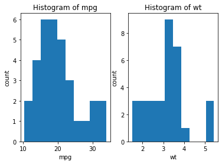

```python
fig, axs = plt.subplots(1,2)
axs[0].set_xlabel("mpg")
axs[0].set_ylabel("count")
axs[0].set_title("Histogram of mpg")
axs[0].hist(mtcars['mpg'])

axs[1].set_xlabel("wt")
axs[1].set_ylabel("count")
axs[1].set_title("Histogram of wt")
axs[1].hist(mtcars['wt'], bins=10)
plt.show()
```

**plt.subplots(a,b)** gives `a` rows with `b` plots on each row. Using the argument `density` when calling **plt.hist()**, we can plot a histogram with relative frequencies instead of frequencies. Such histograms can be viewed as estimates of the density function of the data.

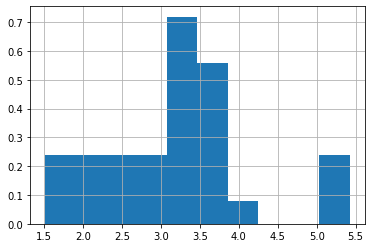

```python
mtcars['wt'].hist(bins=10, density=True)
plt.show()

#alternatively:
#plt.hist(mtcars['wt'], bins=10, density=True)
#plt.show()
```

#### Boxplots

A boxplot is also a useful tool for studying data. It shows the median, quartiles, and possible outliers. The command is **plt.boxplot()**:

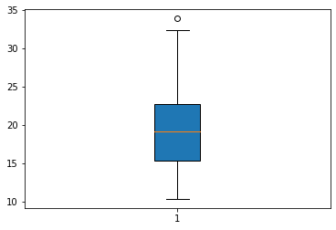

```python
plt.boxplot(mtcars['mpg'],patch_artist=True,vert=True)
plt.show()

#plt.boxplot([mtcars['mpg'],mtcars['wt']],patch_artist=True,vert=True)   #multiple boxplots
#plt.show()
```

#### Scatter plots

Scatterplots are useful for studying dependencies between variables. Try writing:

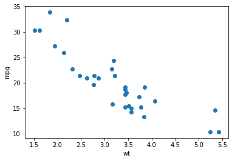

```python
plt.xlabel('wt')
plt.ylabel('mpg')
plt.scatter(mtcars['wt'],mtcars['mpg'])
plt.show()
```

Does a negative slope seem reasonable in this case? The correlation (which measures linear dependence) can be calculated using the command **corr()** (pandas) or **corrcoef()** (numpy). What is the correlation in this case? Does it agree with the slope?

```python
mtcars['mpg'].corr(mtcars['wt'])                 #using pandas
#np.corrcoef(mtcars['mpg'],mtcars['wt'])[0][1]   #using numpy
```

```
-0.8676593765172279
```

1. Plot histograms for the variables hp and qsec.
2. Plot boxplots for hp and qsec.
3. Plot scatter plots for hp and qsec. Comments?

## Simulation of random numbers

Numpy includes routines for simulating random numbers from common distributions. We will study random number generation from two continuous distributions; the normal distribution with mean $\mu$ and variance $\sigma^2$, i.e. with density function:

$f_X(x) = \dfrac{1}{\sigma \sqrt{2 \pi}} e^{-(x-\mu)^2 / (2\sigma^2)}, \hspace{1em} -\infty < x < \infty$

and the exponential distribution with rate $\lambda$ and density:

$f_X(x) = \lambda e^{-\lambda x}, \hspace{1em} 0 < x < \infty$

Simulation of random numbers is done with **np.random.normal()** and **np.random.exponential()**. Which parametrization of the exponential distribution is used in this case? Try the following commands:

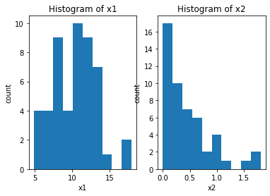

```python
n = 50
mu, sigma = 10, 3; x1 = np.random.normal(mu, sigma, size=n) #normal distribution
rate = 2; x2 = np.random.exponential(1/rate, size=n)        #exponential distribution

fig, axs = plt.subplots(1,2)
axs[0].set_xlabel("x1")
axs[0].set_ylabel("count")
axs[0].set_title("Histogram of x1")
axs[0].hist(x1)

axs[1].set_xlabel("x2")
axs[1].set_ylabel("count")
axs[1].set_title("Histogram of x2")
axs[1].hist(x2)
plt.show()
```

It can be of interest to plot the true density function of the simulated random variables on top of the histograms. Note that the scales of the x-axis and y-axis can be choosen wisely using the commands **plt.xlim()** and **plt.ylim()** as shown below. We make a new plot for the normal distribution as follows:

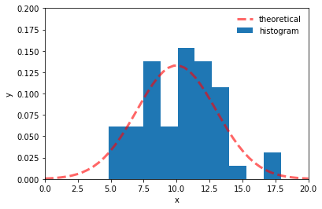

```python
from scipy import stats

mu = 10; sigma = 3
x = np.linspace(0,20,50); y = stats.norm.pdf(x, loc=mu, scale=sigma);

plt.plot(x,y,'r--',lw=3,alpha=0.6,label='theoretical')
#plt.plot(x,y,color='red',ls='dashed',lw=3,label='theoretical')    #alternatively
plt.hist(x1,density=True,label='histogram')

plt.xlabel('x')
plt.ylabel('y')
plt.legend(loc='best',frameon=False)   #no frame/box for legend text
plt.xlim([0,20])
plt.ylim([0,0.2])
plt.show()
```

What will happen if we increase the number $n$ of simulated numbers? To investigate, we add two more histograms to the plot:

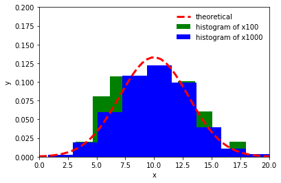

```python
mu = 10; sigma = 3
x = np.linspace(0,20,50); y = stats.norm.pdf(x, loc=mu, scale=sigma);
plt.plot(x,y,'r--',lw=3,label='theoretical')

x100 = np.random.normal(size=100, loc=mu, scale=sigma)
plt.hist(x100,density=True,color='green', label='histogram of x100')

x1000 = np.random.normal(size=1000, loc=mu, scale=sigma)
plt.hist(x1000,density=True,color='blue', label='histogram of x1000')

plt.xlabel('x')
plt.ylabel('y')
plt.legend(loc='best',frameon=False)
plt.xlim([0,20])
plt.ylim([0,0.2])
plt.show()
```

We turn our attention to a less well-behaved distribution. A standard Cauchy variable has the density function:

$f_X(x) = \dfrac{1}{\pi (1+x^2)}, \hspace{1em} -\infty < x < \infty$

It can be shown that mean and variance do not exist for the Cauchy distribution (while the median and mode are 0). We can investigate this numerically by plotting the observations of simulated Cauchy variables a few times. Repeat the following command to see how 100 generated Cauchy variables can vary from one run to the next:

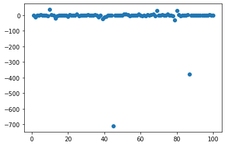

```python
s = np.random.standard_cauchy(100)
plt.scatter(np.arange(1,len(s)+1),s)
plt.show()
```

## More advanced use of Python

Eventually you might want to use Python for somewhat more advanced programming. It is assumed that you are already familiar with programming; in particular that you have seen *if* conditions and loops before.

### A second look at vectors

We've seen that vectors can be created using **np.arange()**. Another alternative is **np.repeat()** which gives us vectors with certain patterns.

```python
x = np.repeat(1, 10)        #array([1,1,1,1,1,1,1,1,1,1])
y = np.tile([1,2,3], 2)     #array([1,2,3,1,2,3])
z = np.repeat([1,2],[2,3])  #array([1,1,2,2,2])
```

Specific elements of vectors can be accessed using clever expressions for indexing. Here are some examples:

x[n] #the n:th index of x (starting 0)

np.delete(x,n) #all elements but the n:th index

b = [a for i,a in enumerate(x) if i!=3] #all elements except that of index 3 (list comprehension approach)

np.delete(x,[2,5]) #all elements except of index 2 and 5

x[a:b] #all elements between the a:th and the b:th index (excluding the b:th)

x[[1,3,7]] #the first, the third, and the seventh indexed elements

x[x>2] #all elements that are greater than 2

### Programming

#### if statements and booleans

Boolean expressions can be written in Python in much the same way as in many other programming languages. Here are some examples:

```python
a = 1; b = 2; c = 3

a==a #checks if a equals a
a==b #checks if a equals b
a!=b #checks if a does not equal b
a<b  #checks if a is less than b
a<=b #checks if a is less than or equal to b

a<b and a<c    #checks if a is less than b _and_ if a is less than c
(a<b) & (a<c)  #checks if a is less than b _and_ if a is less than c

a<b or c<a     #checks if a is less than b or c is less than a
(a<b) | (c<a); #checks if a is less than b or c is less than a
```

Each expression returns either *True* or *False*. Boolean variables are variables that take either of these values. Boolean expressions are useful when using *if* statements. These can be used to make sure that certain parts of the code only run under special conditions. Here is an example of what an *if* statement looks like in Python:

```python
iIsLarge = False; i = 20

if (i >= 10):
    iIsLarge = True  #checks if i is large

iIsLarge #the boolean variable that tells us if i is large
```

```
True
```

*if* can also be combined with *else* to control what happens if the boolean expression is false:

```python
i = np.random.uniform(low=0,high=20,size=1) #a random number between 0 and 20

if (i >= 10):
    iIsLarge = True
else:
    iIsLarge = False

iIsLarge
```

```
True
```

#### Loops

Booleans can also be used in a *while* loop as follows:

```python
count=0; ourRandomNumber = np.random.uniform(low=0,high=40,size=1)

while (ourRandomNumber > 10):
    newRandomNumber = np.random.uniform(low=0,high=40,size=1)
    ourRandomNumber = newRandomNumber
    count = count+1  #counts the number of iterations of the loop

count
```

```
1
```

An alternative is the *for* loop:

```python
x = np.repeat(np.nan,10)

for i in range(10):
    x[i] = (i+1)**2

x
```

```
array([  1.,   4.,   9.,  16.,  25.,  36.,  49.,  64.,  81., 100.])
```

Althought it is considered to be bad practice, the *break* command can be used to stop loops:

```python
x = np.repeat(np.nan,10)

for i in range(10):
    x[i] = (i+1)**2
    if ((i+1)**2 > 10):
        break
x
```

```
array([ 1.,  4.,  9., 16., nan, nan, nan, nan, nan, nan])
```

#### Functions

Creating new functions in Python is quite easy. Consider the following example:

```python
def powern(x, n=2):
    z = x**n
    return z
```

This creates a function **powern()** which takes two arguments, a vector (or scalar) `x` and a vector (or scalar) `n`. If the argument `n` is not given in the call then the default value `n=2` is used. The function returns `x^n`.

The function can now be called just as any other function:

```python
powern(2)
powern(3,1/2)
powern(6,-1)
x = np.array([1,2,3]); powern(x,x)
```

```
array([ 1,  4, 27])
```

### Files and scripts

#### Saving text files

```python
mtcars.to_csv('./mtcars_saved.csv')
```

#### Saving graphics

Figures can be saved manually. However, an alternative is to save the figure by using **plt.savefig()**:

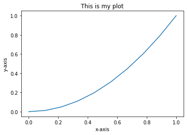

```python
x = np.linspace(0,1,10)
y = x**2

plt.xlabel('x-axis')
plt.ylabel('y-axis')
plt.title('This is my plot')
plt.plot(x,y)

plt.savefig('./sample_figure.png') #as png image
plt.savefig('./sample_figure.pdf') #as pdf
```

#### Executing scripts

If we've saved a Python script in the file "script.py" and want to execute it, we can write:

```python
#exec(open('./script_name.py').read())
```